# feather-data-checks

Inigo Peng, edited by Badhia Yunes-Katz

2025-07-15

# Database Tables

## Feather

### catch

**- Findings catch:**

- Date ranges are the same
- life stage in edi data has not gone through wrangling

#### Date Range Check

*EDI `date`*

```r
range(catch_feather_edi$date)
```

```
## [1] "1997-12-23" "2025-05-16"
```

*DB `date`*

```
## [1] "1997-12-23" "2025-05-16"
```

#### ForkLength

*EDI `forkLength`*

- 4.8 % of values in the `forkLength` column are NA.

```
##    Min. 1st Qu.  Median    Mean 3rd Qu.    Max.    NA's
##    0.00   35.00   37.00   44.05   48.00  940.00   11546
```

*DB `fork_length`*

- 4.8 % of values in the `fork_length` column are NA.

```
##    Min. 1st Qu.  Median    Mean 3rd Qu.    Max.    NA's
##    0.00   35.00   37.00   44.05   48.00  940.00   11546
```

*Forklength Exploration Plots*

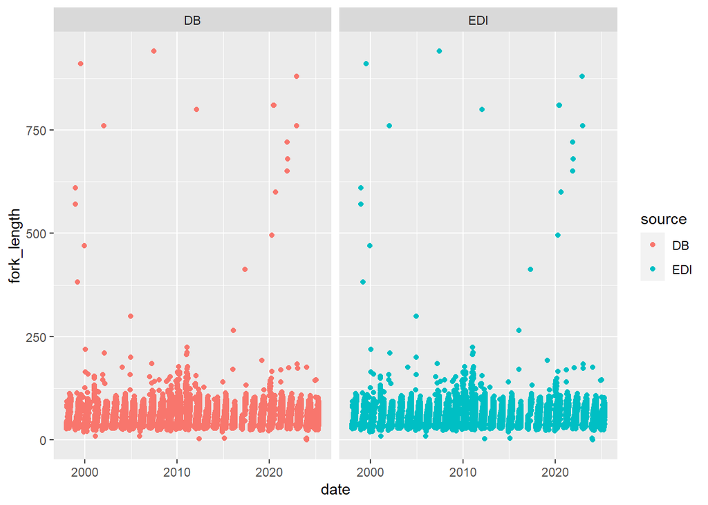

#### Lifestage

(life stage in edi data has not gone through wrangling)

*EDI `lifeStage`*

- 0 % of values in the `lifeStage` column from the EDI data are NA.

*DB `lifestage_id`*

- 0 % of values in the `lifestage_id` column from the database are NA.

#### Count

*EDI `n`*

- 0 % of values in the `n` column in edi data are NA.

```
##      Min.   1st Qu.    Median      Mean   3rd Qu.      Max.
##      1.00      1.00      1.00     62.62      1.00 123556.00
```

*DB `count`*

- 0 % of values in the `count` column in database data are NA.

```
##      Min.   1st Qu.    Median      Mean   3rd Qu.      Max.
##      1.00      1.00      1.00     62.62      1.00 123556.00
```

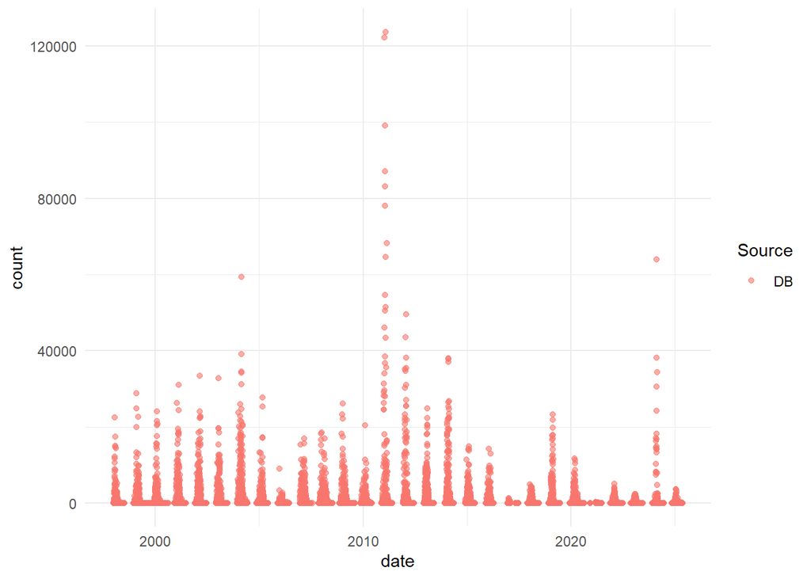

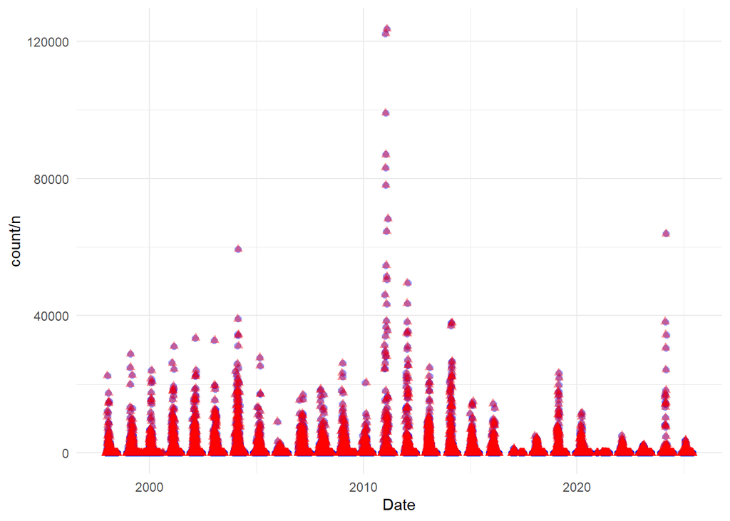

Random pick of data entry to compare between db and EDI

- test 1

```
## Rows: 1
## Columns: 17
## $ id               <int> 4518199
## $ catch_raw_id     <chr> "55171"
## $ trap_location_id <int> 23
## $ date             <date> 2005-03-04
## $ count            <dbl> 1
## $ run_id           <int> 3
## $ lifestage_id     <int> 5
## $ adipose_clipped  <lgl> FALSE
## $ dead             <lgl> NA
## $ fork_length      <dbl> 33
## $ weight           <dbl> NA
## $ actual_count     <lgl> TRUE
## $ updated_at       <dttm> 2025-07-14 08:58:58
## $ stream           <chr> "feather river"
## $ site             <chr> "herringer riffle"
## $ subsite          <chr> "herringer_west"
## $ source           <chr> "DB"
```

```
## Rows: 1
## Columns: 19
## $ ProjectDescriptionID <dbl> 2
## $ trapVisitID          <dbl> 2749
## $ visitTime            <dttm> 2005-03-04 10:15:00
## $ siteName             <chr> "Herringer Riffle"
## $ subSiteName          <chr> "Herringer_west"
## $ visitType            <chr> "Continue trapping"
## $ catchRawID           <dbl> 55171
## $ commonName           <chr> "Chinook salmon"
## $ run                  <chr> "Fall"
## $ fishOrigin           <chr> "Natural"
## $ lifeStage            <chr> "Parr"
## $ forkLength           <dbl> 33
## $ totalLength          <dbl> NA
## $ n                    <dbl> 1
## $ actualCount          <chr> "Yes"
## $ releaseID            <dbl> 0
## $ stream               <chr> "feather river"
## $ date                 <date> 2005-03-04
## $ source               <chr> "EDI"
```

- test 2

```
## Rows: 1
## Columns: 17
## $ id               <int> 4467312
## $ catch_raw_id     <chr> "73"
## $ trap_location_id <int> 18
## $ date             <date> 1997-12-28
## $ count            <dbl> 125
## $ run_id           <int> 6
## $ lifestage_id     <int> 4
## $ adipose_clipped  <lgl> FALSE
## $ dead             <lgl> NA
## $ fork_length      <dbl> NA
## $ weight           <dbl> NA
## $ actual_count     <lgl> TRUE
## $ updated_at       <dttm> 2025-07-14 08:58:58
## $ stream           <chr> "feather river"
## $ site             <chr> "eye riffle"
## $ subsite          <chr> "eye riffle_north"
## $ source           <chr> "DB"
```

```
## Rows: 1
## Columns: 19
## $ ProjectDescriptionID <dbl> 2
## $ trapVisitID          <dbl> 9
## $ visitTime            <dttm> 1997-12-28 09:11:00
## $ siteName             <chr> "Eye Riffle"
## $ subSiteName          <chr> "Eye riffle_north"
## $ visitType            <chr> "Continue trapping"
## $ catchRawID           <dbl> 73
## $ commonName           <chr> "Chinook salmon"
## $ run                  <chr> "Not recorded"
## $ fishOrigin           <chr> "Natural"
## $ lifeStage            <chr> "Not recorded"
## $ forkLength           <dbl> NA
## $ totalLength          <dbl> NA
## $ n                    <dbl> 125
## $ actualCount          <chr> "Yes"
## $ releaseID            <dbl> 0
## $ stream               <chr> "feather river"
## $ date                 <date> 1997-12-28
## $ source               <chr> "EDI"
```

- test 3

```
## Rows: 1
## Columns: 17
## $ id               <int> 4479587
## $ catch_raw_id     <chr> "41525"
## $ trap_location_id <int> 18
## $ date             <date> 2003-12-17
## $ count            <dbl> 2
## $ run_id           <int> 2
## $ lifestage_id     <int> 2
## $ adipose_clipped  <lgl> FALSE
## $ dead             <lgl> NA
## $ fork_length      <dbl> 37
## $ weight           <dbl> NA
## $ actual_count     <lgl> TRUE
## $ updated_at       <dttm> 2025-07-14 08:58:58
## $ stream           <chr> "feather river"
## $ site             <chr> "eye riffle"
## $ subsite          <chr> "eye riffle_north"
## $ source           <chr> "DB"
```

```
## Rows: 1
## Columns: 19
## $ ProjectDescriptionID <dbl> 2
## $ trapVisitID          <dbl> 2133
## $ visitTime            <dttm> 2003-12-17 10:45:00
## $ siteName             <chr> "Eye Riffle"
## $ subSiteName          <chr> "Eye riffle_north"
## $ visitType            <chr> "Continue trapping"
## $ catchRawID           <dbl> 41525
## $ commonName           <chr> "Chinook salmon"
## $ run                  <chr> "Spring"
## $ fishOrigin           <chr> "Natural"
## $ lifeStage            <chr> "Fry"
## $ forkLength           <dbl> 37
## $ totalLength          <dbl> NA
## $ n                    <dbl> 2
## $ actualCount          <chr> "Yes"
## $ releaseID            <dbl> 0
## $ stream               <chr> "feather river"
## $ date                 <date> 2003-12-17
## $ source               <chr> "EDI"
```

### trap

**- Findings trap:**

#### Date Range Check

*DB `trap_visit_time_start`*

```
## [1] "1997-12-22 10:40:00 UTC" "2025-05-16 13:15:12 UTC"
```

*EDI `visitTime`*

```r
range(trap_feather_edi$visitTime)
```

```
## [1] "1997-12-22 10:40:00 UTC" "2025-05-16 13:15:12 UTC"
```

#### counteratend/total_revolution

*DB `total_revolutions`*

- 30.4 % of values in the `total_revolutions` column are NA.

```
##    Min. 1st Qu.  Median    Mean 3rd Qu.    Max.    NA's
##       0    2856    4465    4683    6127   51775    3168
```

*EDI `counterAtEnd`*

- 30.4 % of values in the `counterAtEnd` column are NA.

```
##    Min. 1st Qu.  Median    Mean 3rd Qu.    Max.    NA's
##       0    2856    4465    4683    6127   51775    3168
```

#### fishProcessed

*DB `fish_processed_id`*

- 0 % of values in the `fish_processed_id` column are NA.

```
##
##    1    2    3    4    5
##  859 9317  114   37   96
```

*EDI `fishProcessed`*

- 0 % of values in the `fishProcessed` column are NA.

```
##
## No catch data; fish left in live box         No catch data; fish released
##                                   96                                   37
##                  No fish were caught                       Not applicable
##                                  114                                  859
##                       Processed fish
##                                 9317
```

Random pick of data entry by date to compare between db and EDI

- test 1

```
## Rows: 1
## Columns: 25
## $ id                         <int> 308050
## $ trap_location_id           <int> 21
## $ trap_visit_id              <chr> "23"
## $ visit_type_id              <int> 2
## $ trap_visit_time_start      <dttm> 1998-01-05 11:16:00
## $ trap_visit_time_end        <dttm> NA
## $ trap_functioning_id        <int> 1
## $ in_half_cone_configuration <lgl> NA
## $ fish_processed_id          <int> 2
## $ rpm_start                  <dbl> NA
## $ rpm_end                    <dbl> 2.6
## $ total_revolutions          <dbl> NA
## $ debris_volume              <dbl> NA
## $ debris_level_id            <int> NA
## $ discharge                  <dbl> NA
## $ water_velocity             <dbl> NA
## $ water_temp                 <dbl> 8.888889
## $ turbidity                  <dbl> NA
## $ include                    <lgl> TRUE
## $ updated_at                 <dttm> 2025-07-14 09:02:08
## $ updated_by                 <chr> "AdminJPE"
## $ stream                     <chr> "feather river"
## $ site                       <chr> "live oak"
## $ subsite                    <chr> "live oak"
## $ source                     <chr> "DB"
```

```
## Rows: 1
## Columns: 17
## $ projectDescriptionID  <dbl> 2
## $ trapVisitID           <dbl> 23
## $ visitTime             <dttm> 1998-01-05 11:16:00
## $ siteName              <chr> "Live Oak"
## $ subSiteName           <chr> "Live Oak"
## $ visitType             <chr> "Continue trapping"
## $ fishProcessed         <chr> "Processed fish"
## $ trapFunctioning       <chr> "Not recorded"
## $ counterAtEnd          <dbl> NA
## $ rpmRevolutionsAtStart <dbl> NA
## $ rpmRevolutionsAtEnd   <dbl> 2.6
## $ includeCatch          <chr> "Yes"
## $ waterTemp             <dbl> 8.888889
## $ turbidity             <dbl> NA
## $ stream                <chr> "feather river"
## $ date                  <date> 1998-01-05
## $ source                <chr> "EDI"
```

- test 2

```
## Rows: 1
## Columns: 25
## $ id                         <int> 302663
## $ trap_location_id           <int> 24
## $ trap_visit_id              <chr> "2144"
## $ visit_type_id              <int> 2
## $ trap_visit_time_start      <dttm> 2003-12-22 15:00:00
## $ trap_visit_time_end        <dttm> NA
## $ trap_functioning_id        <int> 2
## $ in_half_cone_configuration <lgl> NA
## $ fish_processed_id          <int> 2
## $ rpm_start                  <dbl> NA
## $ rpm_end                    <dbl> 5.9
## $ total_revolutions          <dbl> NA
## $ debris_volume              <dbl> NA
## $ debris_level_id            <int> NA
## $ discharge                  <dbl> NA
## $ water_velocity             <dbl> NA
## $ water_temp                 <dbl> 9
## $ turbidity                  <dbl> NA
## $ include                    <lgl> TRUE
## $ updated_at                 <dttm> 2025-07-14 09:02:08
## $ updated_by                 <chr> "AdminJPE"
## $ stream                     <chr> "feather river"
## $ site                       <chr> "herringer riffle"
## $ subsite                    <chr> "herringer_east"
## $ source                     <chr> "DB"
```

```
## Rows: 1
## Columns: 17
## $ projectDescriptionID  <dbl> 2
## $ trapVisitID           <dbl> 2144
## $ visitTime             <dttm> 2003-12-22 15:00:00
## $ siteName              <chr> "Herringer Riffle"
## $ subSiteName           <chr> "Herringer_east"
## $ visitType             <chr> "Continue trapping"
## $ fishProcessed         <chr> "Processed fish"
## $ trapFunctioning       <chr> "Trap functioning normally"
## $ counterAtEnd          <dbl> NA
## $ rpmRevolutionsAtStart <dbl> NA
## $ rpmRevolutionsAtEnd   <dbl> 5.9
## $ includeCatch          <chr> "Yes"
## $ waterTemp             <dbl> 9
## $ turbidity             <dbl> NA
## $ stream                <chr> "feather river"
## $ date                  <date> 2003-12-22
## $ source                <chr> "EDI"
```

- test 3

```
## Rows: 1
## Columns: 25
## $ id                         <int> 302071
## $ trap_location_id           <int> 23
## $ trap_visit_id              <chr> "2327"
## $ visit_type_id              <int> 2
## $ trap_visit_time_start      <dttm> 2004-03-07 13:00:00
## $ trap_visit_time_end        <dttm> NA
## $ trap_functioning_id        <int> 2
## $ in_half_cone_configuration <lgl> NA
## $ fish_processed_id          <int> 2
## $ rpm_start                  <dbl> 4.1
## $ rpm_end                    <dbl> NA
## $ total_revolutions          <dbl> 5643
## $ debris_volume              <dbl> NA
## $ debris_level_id            <int> NA
## $ discharge                  <dbl> NA
## $ water_velocity             <dbl> NA
## $ water_temp                 <dbl> 10.2
## $ turbidity                  <dbl> 3.09
## $ include                    <lgl> TRUE
## $ updated_at                 <dttm> 2025-07-14 09:02:08
## $ updated_by                 <chr> "AdminJPE"
## $ stream                     <chr> "feather river"
## $ site                       <chr> "herringer riffle"
## $ subsite                    <chr> "herringer_west"
## $ source                     <chr> "DB"
```

```
## Rows: 1
## Columns: 17
## $ projectDescriptionID  <dbl> 2
## $ trapVisitID           <dbl> 2327
## $ visitTime             <dttm> 2004-03-07 13:00:00
## $ siteName              <chr> "Herringer Riffle"
## $ subSiteName           <chr> "Herringer_west"
## $ visitType             <chr> "Continue trapping"
## $ fishProcessed         <chr> "Processed fish"
## $ trapFunctioning       <chr> "Trap functioning normally"
## $ counterAtEnd          <dbl> 5643
## $ rpmRevolutionsAtStart <dbl> 4.1
## $ rpmRevolutionsAtEnd   <dbl> NA
## $ includeCatch          <chr> "Yes"
## $ waterTemp             <dbl> 10.2
## $ turbidity             <dbl> 3.09
## $ stream                <chr> "feather river"
## $ date                  <date> 2004-03-07
## $ source                <chr> "EDI"
```

### recapture

**- Findings recapture:**

- Date ranges are the same

#### Date Range Check

*DB `date`*

```
## [1] "1999-02-05" "2025-03-29"
```

*EDI `date`*

```r
range(recapture_feather_edi$date)
```

```
## [1] "1999-02-05" "2025-03-29"
```

#### Count

*DB `count`*

- 0 % of values in the `count` column are NA.

```
##    Min. 1st Qu.  Median    Mean 3rd Qu.    Max.
##    0.00    1.00    2.00   12.24    8.00  349.00
```

*EDI `n`*

- 0 % of values in the `n` column are NA.

```r
summary(recapture_feather_edi$n)
```

```
##    Min. 1st Qu.  Median    Mean 3rd Qu.    Max.
##    0.00    1.00    2.00   12.24    8.00  349.00
```

#### lifeStage

*EDI `lifeStage`*

- 0 % of values in the `lifeStage` column are NA.

```
##
##          Fry Not recorded         Parr Silvery parr
##          288         2190          320            4
```

*DB `lifestage_id`*

- 0 % of values in the `lifestage_id` column are NA.

```
##
##    2    4    5    6
##  288 2190  320    4
```

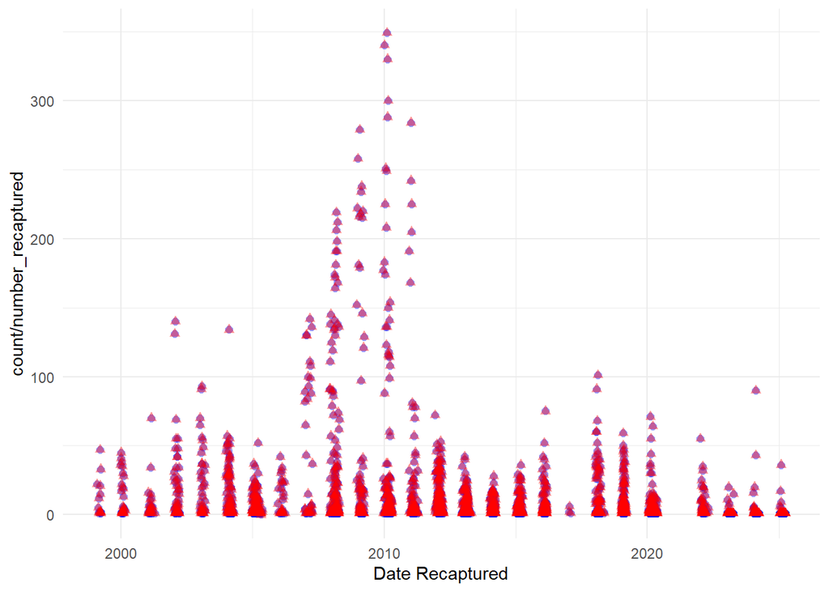

#### forkLength

*EDI `forkLength`*

- 74.1 % of values in the `forkLength` column are NA.

*DB `fork_length`*

- 74.1 % of values in the `fork_length` column are NA.

#### Run

*EDI `run`*

- 15 % of values in the `run` column are NA.

```
##
##         Fall Not recorded       Spring
##         1559          821            1
```

*DB `run_id`*

- 0 % of values in the `run_id` column are NA.

```
##
##    2    3    5    6
##    1 1559  421  821
```

Random pick of data entry to compare between db and EDI

- test 1

```
## Rows: 1
## Columns: 17
## $ id               <int> 35991
## $ trap_location_id <int> 21
## $ catch_raw_id     <int> 215015
## $ date             <date> 1999-12-22
## $ count            <dbl> 36
## $ run_id           <int> 6
## $ lifestage_id     <int> 4
## $ adipose_clipped  <lgl> FALSE
## $ dead             <lgl> NA
## $ fork_length      <dbl> NA
## $ weight           <dbl> NA
## $ release_id       <chr> "15"
## $ updated_at       <dttm> 2025-07-14 09:02:03
## $ stream           <chr> "feather river"
## $ site             <chr> "live oak"
## $ subsite          <chr> "live oak"
## $ source           <chr> "DB"
```

```
## Rows: 1
## Columns: 21
## $ ProjectDescriptionID <dbl> 2
## $ catchRawID           <dbl> 215015
## $ trapVisitID          <dbl> 845
## $ commonName           <chr> "Chinook salmon"
## $ releaseID            <dbl> 15
## $ run                  <chr> "Not recorded"
## $ fishOrigin           <chr> "Unknown"
## $ lifeStage            <chr> "Not recorded"
## $ forkLength           <dbl> NA
## $ n                    <dbl> 36
## $ visitTime            <dttm> 1999-12-22 15:00:00
## $ visitType            <chr> "Continue trapping"
## $ siteName             <chr> "Live Oak"
## $ subSiteName          <chr> "Live Oak"
## $ markType             <chr> "Pigment / dye"
## $ markColor            <chr> "Brown"
## $ markPosition         <chr> "Whole body"
## $ markCode             <lgl> NA
## $ stream               <chr> "feather river"
## $ date                 <date> 1999-12-22
## $ source               <chr> "EDI"
```

- test 2

```
## Rows: 1
## Columns: 17
## $ id               <int> 36461
## $ trap_location_id <int> 24
## $ catch_raw_id     <int> 234245
## $ date             <date> 2008-02-06
## $ count            <dbl> 3
## $ run_id           <int> 5
## $ lifestage_id     <int> 4
## $ adipose_clipped  <lgl> FALSE
## $ dead             <lgl> NA
## $ fork_length      <dbl> NA
## $ weight           <dbl> NA
## $ release_id       <chr> "240"
## $ updated_at       <dttm> 2025-07-14 09:02:03
## $ stream           <chr> "feather river"
## $ site             <chr> "herringer riffle"
## $ subsite          <chr> "herringer_east"
## $ source           <chr> "DB"
```

```
## Rows: 1
## Columns: 21
## $ ProjectDescriptionID <dbl> 2
## $ catchRawID           <dbl> 234245
## $ trapVisitID          <dbl> 3653
## $ commonName           <chr> "Chinook salmon"
## $ releaseID            <dbl> 240
## $ run                  <chr> NA
## $ fishOrigin           <chr> "Natural"
## $ lifeStage            <chr> "Not recorded"
## $ forkLength           <dbl> NA
## $ n                    <dbl> 3
## $ visitTime            <dttm> 2008-02-06 12:00:00
## $ visitType            <chr> "Continue trapping"
## $ siteName             <chr> "Herringer Riffle"
## $ subSiteName          <chr> "Herringer_east"
## $ markType             <chr> "Pigment / dye"
## $ markColor            <chr> "Brown"
## $ markPosition         <chr> "Whole body"
## $ markCode             <lgl> NA
## $ stream               <chr> "feather river"
## $ date                 <date> 2008-02-06
## $ source               <chr> "EDI"
```

- test 3

```
## Rows: 1
## Columns: 17
## $ id               <int> 38331
## $ trap_location_id <int> 25
## $ catch_raw_id     <int> 76916066
## $ date             <date> 2024-02-12
## $ count            <dbl> 1
## $ run_id           <int> 5
## $ lifestage_id     <int> 5
## $ adipose_clipped  <lgl> FALSE
## $ dead             <lgl> NA
## $ fork_length      <dbl> 51
## $ weight           <dbl> NA
## $ release_id       <chr> "922"
## $ updated_at       <dttm> 2025-07-14 09:02:03
## $ stream           <chr> "feather river"
## $ site             <chr> "herringer riffle"
## $ subsite          <chr> "herringer_upper_west"
## $ source           <chr> "DB"
```

```
## Rows: 1
## Columns: 21
## $ ProjectDescriptionID <dbl> 2
## $ catchRawID           <dbl> 76916066
## $ trapVisitID          <dbl> 10143
## $ commonName           <chr> "Chinook salmon"
## $ releaseID            <dbl> 922
## $ run                  <chr> NA
## $ fishOrigin           <chr> "Natural"
## $ lifeStage            <chr> "Parr"
## $ forkLength           <dbl> 51
## $ n                    <dbl> 1
## $ visitTime            <dttm> 2024-02-12 13:30:36
## $ visitType            <chr> "Continue trapping"
## $ siteName             <chr> "Herringer Riffle"
## $ subSiteName          <chr> "Herringer_Upper_west"
## $ markType             <chr> "Elastomer"
## $ markColor            <chr> "White"
## $ markPosition         <chr> "Nose"
## $ markCode             <lgl> NA
## $ stream               <chr> "feather river"
## $ date                 <date> 2024-02-12
## $ source               <chr> "EDI"
```

### release

**- Findings release:**

- No markedLifeStage in EDI, all lifestage_id are NA in DB

#### Date Range Check

*DB `date_released`*

```
## [1] "1999-02-04 17:00:00 UTC" "2025-04-10 10:12:00 UTC"
```

*EDI `releaseTime`*

```r
range(release_feather_edi$releaseTime)
```

```
## [1] "1999-02-04 17:00:00 UTC" "2025-04-10 10:12:00 UTC"
```

#### origin_id

*EDI `markedFishOrigin`*

- 0 % of values in the `markedFishOrigin` column are NA.

```
##
## Hatchery    Mixed  Natural  Unknown
##       11        2      738      191
```

*DB `origin_id`*

- 0 % of values in the `origin_id` column are NA.

```
##
##   1   2   4   5
## 710   8 150   2
```

#### nReleased

*EDI `nReleased`*

- 0 % of values in the `nReleased` column are NA.

```
##    Min. 1st Qu.  Median    Mean 3rd Qu.    Max.
##     1.0   483.0   759.5   766.1   998.0  4998.0
```

*DB `number_released`*

- 0 % of values in the `number_released` column are NA.

```
##    Min. 1st Qu.  Median    Mean 3rd Qu.    Max.
##     1.0   479.2   757.0   758.7   998.0  4998.0
```

*Exploration Plots*

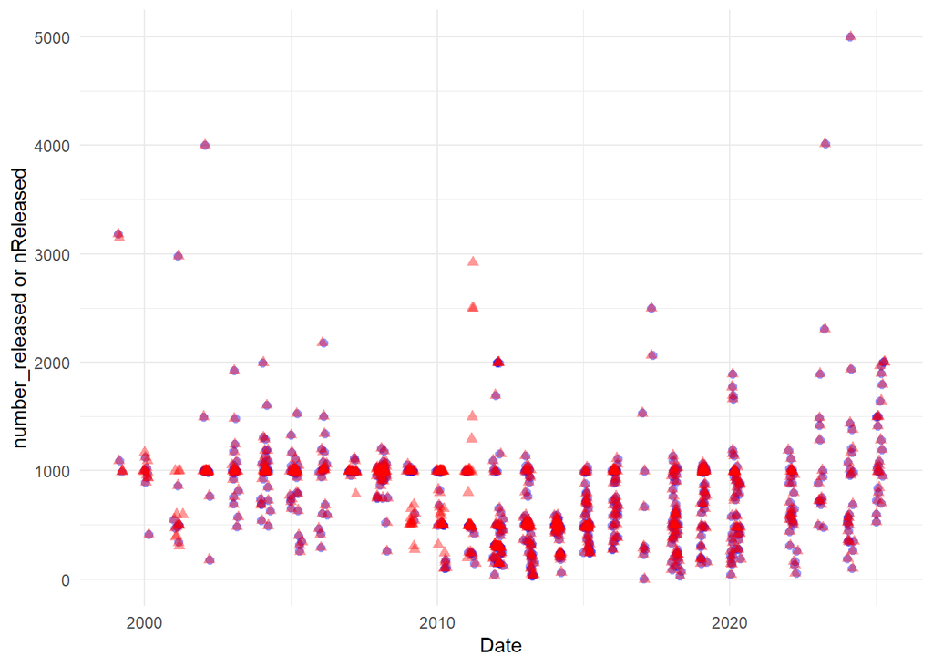

Random pick of data entry by date to compare between db and EDI

- test 1

```
## Rows: 1
## Columns: 15
## $ id                          <int> 4289
## $ trap_location_id            <int> 26
## $ release_id                  <chr> "140"
## $ date_released               <dttm> 2004-12-29 13:30:00
## $ run_id                      <int> 3
## $ median_fork_length_released <dbl> NA
## $ lifestage_id                <int> NA
## $ origin_id                   <int> 1
## $ number_released             <dbl> 1328
## $ updated_at                  <dttm> 2025-07-14 09:02:06
## $ updated_by                  <chr> "AdminJPE"
## $ stream                      <chr> "feather river"
## $ site                        <chr> "herringer riffle"
## $ subsite                     <chr> NA
## $ source                      <chr> "DB"
```

```
## Rows: 1
## Columns: 19
## $ projectDescriptionID <dbl> 2
## $ releaseID            <dbl> 140
## $ releaseTime          <dttm> 2004-12-29 13:30:00
## $ commonName           <chr> "Chinook salmon"
## $ markedRun            <chr> "Fall"
## $ markedFishOrigin     <chr> "Natural"
## $ sourceOfFishSite     <chr> NA
## $ releaseSite          <chr> "Herringer_release site"
## $ releaseSubSite       <chr> "half mile above trap RM"
## $ nReleased            <dbl> 1328
## $ testDays             <dbl> 6
## $ appliedMarkType      <chr> "Elastomer"
## $ appliedMarkColor     <chr> "Orange"
## $ appliedMarkPosition  <chr> "Nose"
## $ appliedMarkCode      <lgl> NA
## $ IncludeInAnalysis    <chr> "Yes"
## $ stream               <chr> "feather river"
## $ date                 <date> 2004-12-29
## $ source               <chr> "EDI"
```

- test 2

```
## Rows: 1
## Columns: 15
## $ id                          <int> 4416
## $ trap_location_id            <int> 30
## $ release_id                  <chr> "231"
## $ date_released               <dttm> 2008-03-13 10:30:00
## $ run_id                      <int> 3
## $ median_fork_length_released <dbl> NA
## $ lifestage_id                <int> NA
## $ origin_id                   <int> 1
## $ number_released             <dbl> 1019
## $ updated_at                  <dttm> 2025-07-14 09:02:06
## $ updated_by                  <chr> "AdminJPE"
## $ stream                      <chr> "feather river"
## $ site                        <chr> "steep riffle"
## $ subsite                     <chr> NA
## $ source                      <chr> "DB"
```

```
## Rows: 1
## Columns: 19
## $ projectDescriptionID <dbl> 2
## $ releaseID            <dbl> 231
## $ releaseTime          <dttm> 2008-03-13 10:30:00
## $ commonName           <chr> "Chinook salmon"
## $ markedRun            <chr> "Fall"
## $ markedFishOrigin     <chr> "Natural"
## $ sourceOfFishSite     <chr> NA
## $ releaseSite          <chr> "Steep Riffle_release site"
## $ releaseSubSite       <chr> "Not applicable (n/a)"
## $ nReleased            <dbl> 1019
## $ testDays             <dbl> 4
## $ appliedMarkType      <chr> "Elastomer"
## $ appliedMarkColor     <chr> "Green"
## $ appliedMarkPosition  <chr> "Nose"
## $ appliedMarkCode      <lgl> NA
## $ IncludeInAnalysis    <chr> "Yes"
## $ stream               <chr> "feather river"
## $ date                 <date> 2008-03-13
## $ source               <chr> "EDI"
```

- test 3

```
## Rows: 1
## Columns: 15
## $ id                          <int> 4666
## $ trap_location_id            <int> 40
## $ release_id                  <chr> "547"
## $ date_released               <dttm> 2014-03-07 12:00:00
## $ run_id                      <int> 3
## $ median_fork_length_released <dbl> NA
## $ lifestage_id                <int> NA
## $ origin_id                   <int> 1
## $ number_released             <dbl> 201
## $ updated_at                  <dttm> 2025-07-14 09:02:06
## $ updated_by                  <chr> "AdminJPE"
## $ stream                      <chr> "feather river"
## $ site                        <chr> "gateway riffle"
## $ subsite                     <chr> NA
## $ source                      <chr> "DB"
```

```
## Rows: 1
## Columns: 19
## $ projectDescriptionID <dbl> 2
## $ releaseID            <dbl> 547
## $ releaseTime          <dttm> 2014-03-07 12:00:00
## $ commonName           <chr> "Chinook salmon"
## $ markedRun            <chr> "Fall"
## $ markedFishOrigin     <chr> "Natural"
## $ sourceOfFishSite     <chr> "Gateway Riffle"
## $ releaseSite          <chr> "Gateway_release site"
## $ releaseSubSite       <chr> "next to Gateway release boxes"
## $ nReleased            <dbl> 201
## $ testDays             <dbl> 3
## $ appliedMarkType      <chr> "Elastomer"
## $ appliedMarkColor     <chr> "Green"
## $ appliedMarkPosition  <chr> "Nose"
## $ appliedMarkCode      <lgl> NA
## $ IncludeInAnalysis    <chr> "Yes"
## $ stream               <chr> "feather river"
## $ date                 <date> 2014-03-07
## $ source               <chr> "EDI"
```

- test 4

```
## Rows: 1
## Columns: 15
## $ id                          <int> 4992
## $ trap_location_id            <int> 26
## $ release_id                  <chr> "901"
## $ date_released               <dttm> 2023-02-09 11:00:00
## $ run_id                      <int> 3
## $ median_fork_length_released <dbl> NA
## $ lifestage_id                <int> NA
## $ origin_id                   <int> 1
## $ number_released             <dbl> 728
## $ updated_at                  <dttm> 2025-07-14 09:02:06
## $ updated_by                  <chr> "AdminJPE"
## $ stream                      <chr> "feather river"
## $ site                        <chr> "herringer riffle"
## $ subsite                     <chr> NA
## $ source                      <chr> "DB"
```

```
## Rows: 1
## Columns: 19
## $ projectDescriptionID <dbl> 2
## $ releaseID            <dbl> 901
## $ releaseTime          <dttm> 2023-02-09 11:00:00
## $ commonName           <chr> "Chinook salmon"
## $ markedRun            <chr> "Fall"
## $ markedFishOrigin     <chr> "Natural"
## $ sourceOfFishSite     <chr> "Eye Riffle"
## $ releaseSite          <chr> "Herringer_release site"
## $ releaseSubSite       <chr> "Herringer release_ RL & RR"
## $ nReleased            <dbl> 728
## $ testDays             <dbl> 7
## $ appliedMarkType      <chr> "Elastomer"
## $ appliedMarkColor     <chr> "White"
## $ appliedMarkPosition  <chr> "Nose"
## $ appliedMarkCode      <lgl> NA
## $ IncludeInAnalysis    <chr> "Yes"
## $ stream               <chr> "feather river"
## $ date                 <date> 2023-02-09
## $ source               <chr> "EDI"
```

### releasefish

**- Findings releasefish:**

#### column names

*EDI*

```
##  [1] "projectDescriptionID"        "releaseFishID"
##  [3] "releaseID"                   "forkLength"
##  [5] "id"                          "trap_location_id"
##  [7] "date_released"               "run_id"
##  [9] "median_fork_length_released" "lifestage_id"
## [11] "origin_id"                   "number_released"
## [13] "updated_at"                  "updated_by"
```

*DB*

```
## [1] "id"               "trap_location_id" "release_id"       "fork_length"
## [5] "updated_at"       "release_fish_id"  "stream"           "site"
## [9] "subsite"
```

#### forkLength

*EDI `forkLength`*

- 0.2 % of values in the `forkLength` column are NA.

```
##    Min. 1st Qu.  Median    Mean 3rd Qu.    Max.    NA's
##    0.00   35.00   36.00   37.47   38.00  445.00      81
```

*DB `fork_length`*

- 0.2 % of values in the `fork_length` column are NA.

```
##    Min. 1st Qu.  Median    Mean 3rd Qu.    Max.    NA's
##    0.00   35.00   36.00   37.47   38.00  445.00      81
```